# Leg-pain intensity in primary-care patients with sciatica

## Diagnostics

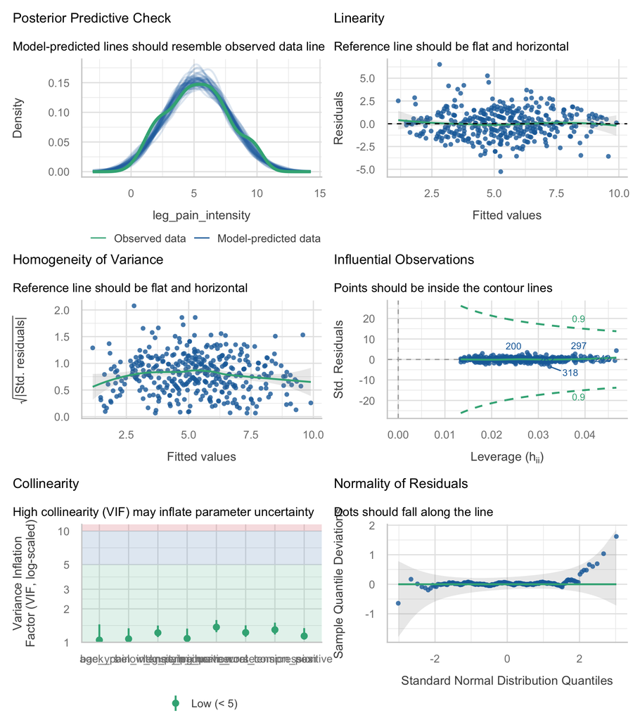

```
## OK: Error variance appears to be homoscedastic (p = 0.208).
```

| Term | VIF | VIF_CI_low | VIF_CI_high | SE_factor | Tolerance | Tolerance_CI_low | Tolerance_CI_high |
| --- | --- | --- | --- | --- | --- | --- | --- |
| age_yrs | 1.047715 | 1.005061 | 1.449864 | 1.023580 | 0.9544580 | 0.6897199 | 0.9949646 |
| sex | 1.139563 | 1.056985 | 1.341808 | 1.067503 | 0.8775294 | 0.7452633 | 0.9460875 |
| back_pain_intensity | 1.073935 | 1.016214 | 1.337144 | 1.036308 | 0.9311554 | 0.7478627 | 0.9840451 |
| leg_pain_duration | 1.082558 | 1.020785 | 1.327916 | 1.020030 | 0.9237382 | 0.7530596 | 0.9796381 |
| below_knee_pain | 1.218852 | 1.115166 | 1.415892 | 1.104017 | 0.8204438 | 0.7062687 | 0.8967278 |
| leg_pain_worse | 1.369990 | 1.233660 | 1.585863 | 1.170466 | 0.7299323 | 0.6305715 | 0.8105963 |
| neural_tension_positive | 1.297274 | 1.175991 | 1.502139 | 1.138979 | 0.7708474 | 0.6657176 | 0.8503470 |
| mri_nerve_root_compression | 1.224477 | 1.119455 | 1.421834 | 1.106561 | 0.8166751 | 0.7033171 | 0.8932922 |

```
## OK: No outliers detected.
## - Based on the following method and threshold: cook (0.8).
## - For variable: (Whole model)
```

**Linearity.** The fitted-versus-residual smooth is essentially flat and the posterior-predictive check tracks the observed distribution reasonably, though simulated values spill below 0 and above 10 where the real scale cannot go. In practice 0 of the 376 fitted values fall outside the 0-10 range, so the bound is not actually being violated at observed covariate patterns; the linear model is adequate here even though it is formally defined on the wrong support.

**Homoscedasticity.** Constant variance is **not** rejected (`check_heteroscedasticity()` p = 0.208), so ordinary standard errors are valid and HC3 re-estimation is not required. Because the outcome is bounded and residual spread narrows near the ceiling, robust standard errors are nevertheless reported below as a sensitivity check.

HC3 robust standard errors (sensitivity)

| Term | SE (OLS) | SE (HC3) | p (OLS) | p (HC3) |
| --- | --- | --- | --- | --- |
| (Intercept) | 0.409 | 0.377 | 0.009 | 0.005 |
| age_yrs | 0.006 | 0.006 | 0.011 | 0.013 |
| sexMale | 0.174 | 0.170 | 0.492 | 0.482 |
| back_pain_intensity | 0.038 | 0.045 | 0.000 | 0.000 |
| leg_pain_duration6-12 weeks | 0.209 | 0.223 | 0.157 | 0.186 |
| leg_pain_duration>12 weeks | 0.187 | 0.184 | 0.115 | 0.109 |
| below_knee_painYes | 0.195 | 0.190 | 0.000 | 0.000 |
| leg_pain_worseYes | 0.187 | 0.179 | 0.000 | 0.000 |
| neural_tension_positiveYes | 0.188 | 0.190 | 0.033 | 0.035 |
| mri_nerve_root_compressionYes | 0.180 | 0.191 | 0.012 | 0.018 |

**Normality of residuals.** Formally **rejected** (`check_normality()` p = 0.006). The Q-Q plot shows mild departure in the tails, driven by the coarse recording of the 0-10 scale in thirds of a point and by the 15 patients piled at the ceiling of 10. With n = 376 the central limit theorem covers the coefficient standard errors, so the practical consequence is small, but this is a genuine assumption failure and should be reported as one rather than waved away.

**Influential points.** `check_outliers()` flags 0 observation(s) at the Cook’s-distance threshold.

**Collinearity.** No problem: the largest variance inflation factor is leg_pain_worse at 1.37, well under 5. `leg_pain_worse` and `below_knee_pain` are correlated but not collinear (VIF 1.37 and 1.22), and `back_pain_intensity` has a VIF of only 1.07 despite correlating 0.6 with the outcome – a useful reminder that VIF concerns predictor-predictor, not predictor-outcome, correlation. Excluding `clinician_sciatica` avoided the one genuine collinearity threat in this file.